# lol_refined

Data source: https://www.kaggle.com/datasets/bobbyscience/league-of-legends-diamond-ranked-games-10-min/data (Riot Games)

# Abstract

This study analyzes a dataset of 9,879 League of Legends matches to identify key predictors of team victory. Using logistic regression and random forest models, we evaluate the impact of various in-game metrics, such as kill difference, dragon control, and experience advantage, on the likelihood of winning. The logistic regression model achieved a McFadden’s R² of 0.229, indicating a moderate fit, while the random forest model highlighted the significance of these predictors through variable importance plots. ROC analysis further validated model performance, with an AUC of 0.8059, demonstrating strong predictive capability. This comprehensive analysis provides valuable insights into strategic factors influencing match outcomes, offering potential applications in competitive gaming strategy development.

# Introduction

In the fast-paced world of esports, understanding what contributes to a team’s victory is crucial for strategy and performance enhancement. This study explores League of Legends (LoL), a popular online game, to identify key factors influencing match outcomes. Utilizing a dataset of 9,879 matches, the research aims to determine which in-game metrics, such as kill difference and dragon control, significantly impact winning.

These metrics are essential for understanding how a team dominates and executes strategies during gameplay. Logistic regression and random forest models are employed to analyze these factors, highlighting their relative importance.

The goal is to provide valuable insights into the game’s dynamics, enabling players to refine strategies and improve their chances of success on the rift.

```r
# Dataframe is imported
lol_df <- read_csv(here("LOL_data.csv"))
glimpse(lol_df)
```

```
## Rows: 9,879
## Columns: 40
## $ gameId                       <dbl> 4519157822, 4523371949, 4521474530, 45243…
## $ blueWins                     <dbl> 0, 0, 0, 0, 0, 1, 1, 0, 0, 1, 0, 0, 1, 0,…
## $ blueWardsPlaced              <dbl> 28, 12, 15, 43, 75, 18, 18, 16, 16, 13, 2…
## $ blueWardsDestroyed           <dbl> 2, 1, 0, 1, 4, 0, 3, 2, 3, 1, 3, 2, 1, 3,…
## $ blueFirstBlood               <dbl> 1, 0, 0, 0, 0, 0, 1, 0, 0, 1, 1, 1, 1, 0,…
## $ blueKills                    <dbl> 9, 5, 7, 4, 6, 5, 7, 5, 7, 4, 4, 11, 7, 4…
## $ blueDeaths                   <dbl> 6, 5, 11, 5, 6, 3, 6, 13, 7, 5, 4, 11, 1,…
## $ blueAssists                  <dbl> 11, 5, 4, 5, 6, 6, 7, 3, 8, 5, 6, 7, 11, …
## $ blueEliteMonsters            <dbl> 0, 0, 1, 1, 0, 1, 1, 0, 0, 1, 0, 1, 1, 1,…
## $ blueDragons                  <dbl> 0, 0, 1, 0, 0, 1, 1, 0, 0, 1, 0, 0, 1, 0,…
## $ blueHeralds                  <dbl> 0, 0, 0, 1, 0, 0, 0, 0, 0, 0, 0, 1, 0, 1,…
## $ blueTowersDestroyed          <dbl> 0, 0, 0, 0, 0, 0, 0, 0, 0, 0, 0, 0, 0, 0,…
## $ blueTotalGold                <dbl> 17210, 14712, 16113, 15157, 16400, 15899,…
```

[output cut: 27 more lines]

# Feature Engineering

```r
lol_df <- lol_df %>%
  # Janitor package used to transform column names for consistency and readability purposes
  clean_names() %>%

  # blue_wins converted to factors for better interpretation and renamed to winning_team
  mutate(blue_wins = factor(blue_wins, levels = c(0, 1), labels = c("Red", "Blue"))) %>%
  rename(winning_team = blue_wins) %>%

  # blue_first_blood reinterpreted to factors and variable kill_diff created
  mutate(blue_first_blood = factor(blue_first_blood, levels = c(0, 1), labels = c("Yes", "No"))) %>%

  # New variables are created to capture important relationships and improve predictive power
  mutate(blue_vision_score = blue_wards_placed + blue_wards_destroyed) %>%
  mutate(red_vision_score = red_wards_placed + red_wards_destroyed) %>%
  mutate(kill_diff = blue_kills - red_kills) %>%
  mutate(blue_dragon_diff = blue_dragons - red_dragons) %>%
  mutate(blue_cs_diff = blue_total_minions_killed - red_total_minions_killed) %>%
  mutate(blue_jgl_cs_diff = blue_total_jungle_minions_killed - red_total_jungle_minions_killed) %>%
  mutate(blue_towers_diff = blue_towers_destroyed - red_towers_destroyed) %>%
  mutate(blue_vs_diff = blue_vision_score - red_vision_score)
```

Exploratory Data Analysis Visualizations are generated to gain insight into key metrics and their impact of winning outcome.

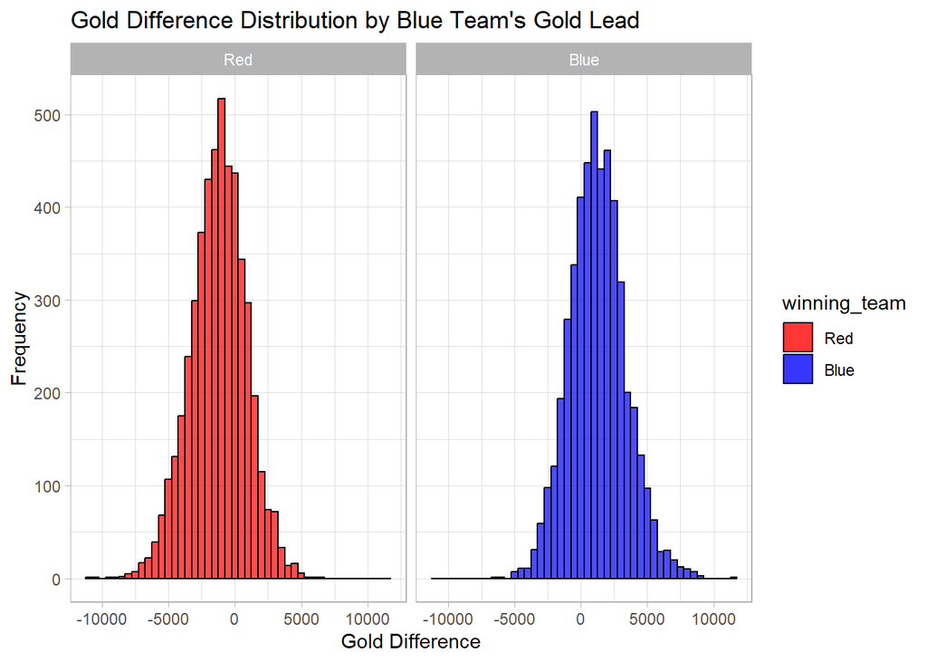

```r
# Histogram and Density Plot: Gold Difference Distribution
ggplot(lol_df, aes(x = blue_gold_diff, fill = winning_team)) +
  geom_histogram(binwidth = 500, color = "black", alpha = 0.7, position = "identity") +
  geom_density(alpha = 0.3, color = "black") +
  labs(title = "Gold Difference Distribution by Blue Team's Gold Lead",
       x = "Gold Difference", y = "Frequency") +
  scale_fill_manual(values = c("Red" = "red", "Blue" = "blue")) +
  theme_light() +
  facet_wrap(~ winning_team)
```

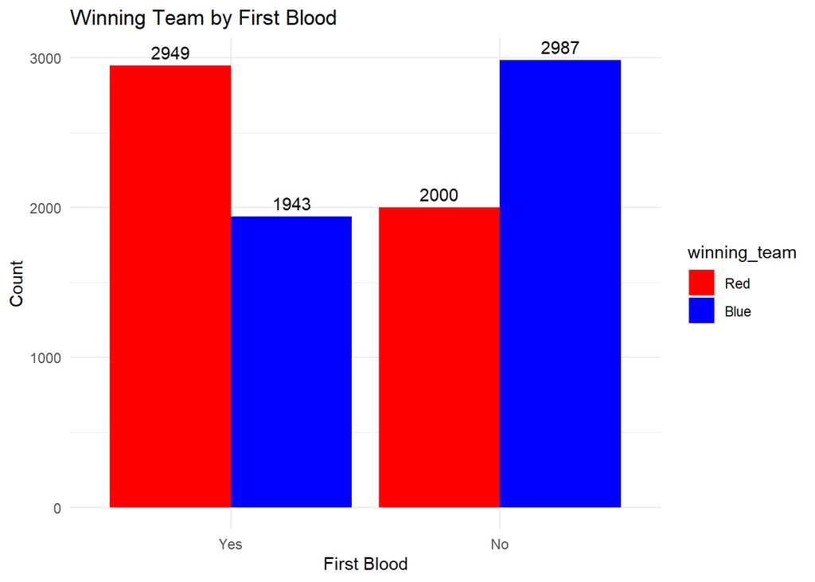

```r
# Bar Plot: Winning Team by First Blood
ggplot(lol_df, aes(x = blue_first_blood, fill = winning_team)) +
  geom_bar(position = "dodge") +
  geom_text(stat = "count", aes(label = ..count..), position = position_dodge(width = 0.9), vjust = -0.5) +
  labs(title = "Winning Team by First Blood",
       x = "First Blood",
       y = "Count") +
  scale_fill_manual(values = c("Red" = "red", "Blue" = "blue")) +
  theme_minimal()
```

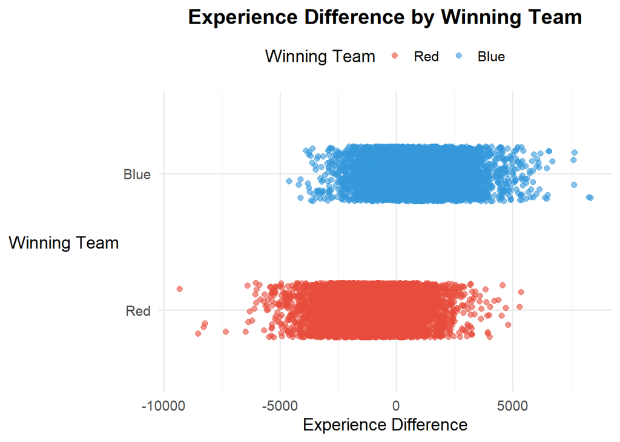

```r
# Jitter Plot: Experience Lead by Winning Team
ggplot(lol_df, aes(x = blue_experience_diff, y = winning_team, color = winning_team)) +
  geom_jitter(width = 0, height = 0.2, alpha = 0.6, size = 2) +
  labs(title = "Experience Difference by Winning Team",
       x = "Experience Difference",
       y = "Winning Team") +
  scale_color_manual(values = c("Red" = "#E74C3C", "Blue" = "#3498DB")) +
  theme_minimal(base_size = 14) +
  theme(
    plot.title = element_text(hjust = 0.5, face = "bold"),
    axis.title.y = element_text(angle = 0, vjust = 0.5),
    legend.position = "top"
  ) +
  guides(color = guide_legend(title = "Winning Team"))
```

# Modelling

```r
# The stepwise approach removes and adds predictors based on AIC score (lower is better) to find the best fitting model. Positive coefficients increase the odd of winning while negative coefficients decrease the odds of winning.
# The model with lowest AIC is examined as well the characteristics of the predictors to decide which ones to select and if any transformations are needed.
model <- glm(winning_team ~ ., data = lol_df, family = binomial)
stepwise_model <- step(model, direction = "both")
```

```
## Start:  AIC=10463.85
## winning_team ~ game_id + blue_wards_placed + blue_wards_destroyed +
##     blue_first_blood + blue_kills + blue_deaths + blue_assists +
##     blue_elite_monsters + blue_dragons + blue_heralds + blue_towers_destroyed +
##     blue_total_gold + blue_avg_level + blue_total_experience +
##     blue_total_minions_killed + blue_total_jungle_minions_killed +
##     blue_gold_diff + blue_experience_diff + blue_cs_per_min +
##     blue_gold_per_min + red_wards_placed + red_wards_destroyed +
##     red_first_blood + red_kills + red_deaths + red_assists +
##     red_elite_monsters + red_dragons + red_heralds + red_towers_destroyed +
##     red_total_gold + red_avg_level + red_total_experience + red_total_minions_killed +
##     red_total_jungle_minions_killed + red_gold_diff + red_experience_diff +
##     red_cs_per_min + red_gold_per_min + blue_vision_score + red_vision_score +
##     kill_diff + blue_dragon_diff + blue_cs_diff + blue_jgl_cs_diff +
##     blue_towers_diff + blue_vs_diff
##
##
## Step:  AIC=10463.85
## winning_team ~ game_id + blue_wards_placed + blue_wards_destroyed +
##     blue_first_blood + blue_kills + blue_deaths + blue_assists +
##     blue_elite_monsters + blue_dragons + blue_heralds + blue_towers_destroyed +
##     blue_total_gold + blue_avg_level + blue_total_experience +
##     blue_total_minions_killed + blue_total_jungle_minions_killed +
##     blue_gold_diff + blue_experience_diff + blue_cs_per_min +
##     blue_gold_per_min + red_wards_placed + red_wards_destroyed +
##     red_first_blood + red_kills + red_deaths + red_assists +
##     red_elite_monsters + red_dragons + red_heralds + red_towers_destroyed +
##     red_total_gold + red_avg_level + red_total_experience + red_total_minions_killed +
##     red_total_jungle_minions_killed + red_gold_diff + red_experience_diff +
##     red_cs_per_min + red_gold_per_min + blue_vision_score + red_vision_score +
##     kill_diff + blue_dragon_diff + blue_cs_diff + blue_jgl_cs_diff +
##     blue_towers_diff
##
##
## Step:  AIC=10463.85
## winning_team ~ game_id + blue_wards_placed + blue_wards_destroyed +
##     blue_first_blood + blue_kills + blue_deaths + blue_assists +
##     blue_elite_monsters + blue_dragons + blue_heralds + blue_towers_destroyed +
##     blue_total_gold + blue_avg_level + blue_total_experience +
##     blue_total_minions_killed + blue_total_jungle_minions_killed +
```

[output cut: 807 more lines]

```
## + blue_total_experience             1    10417 10449
## + red_total_experience              1    10417 10449
## + red_avg_level                     1    10417 10449
## + blue_avg_level                    1    10417 10449
## + red_wards_destroyed               1    10417 10449
## + blue_wards_destroyed              1    10417 10449
## + blue_vision_score                 1    10417 10449
## - blue_deaths                       1    10422 10450
## - blue_kills                        1    10423 10451
## - blue_total_minions_killed         1    10425 10453
## - red_towers_destroyed              1    10425 10453
## - red_total_minions_killed          1    10428 10456
## - blue_dragons                      1    10450 10478
## - blue_experience_diff              1    10493 10521
## - blue_gold_diff                    1    10544 10572
```

```r
summary(stepwise_model)
```

```
##
## Call:
## glm(formula = winning_team ~ blue_wards_placed + blue_first_blood +
##     blue_kills + blue_deaths + blue_dragons + blue_towers_destroyed +
##     blue_total_minions_killed + blue_gold_diff + blue_experience_diff +
##     red_elite_monsters + red_dragons + red_towers_destroyed +
##     red_total_minions_killed + red_total_jungle_minions_killed,
##     family = binomial, data = lol_df)
##
## Coefficients:
##                                   Estimate Std. Error z value Pr(>|z|)
## (Intercept)                     -4.469e-01  4.564e-01  -0.979 0.327449
## blue_wards_placed               -2.189e-03  1.326e-03  -1.651 0.098772 .
## blue_first_bloodNo               8.204e-02  5.216e-02   1.573 0.115757
## blue_kills                      -4.729e-02  2.019e-02  -2.343 0.019153 *
## blue_deaths                      4.748e-02  2.119e-02   2.240 0.025068 *
## blue_dragons                     3.663e-01  6.438e-02   5.689 1.27e-08 ***
## blue_towers_destroyed           -1.940e-01  1.298e-01  -1.495 0.135009
## blue_total_minions_killed       -4.314e-03  1.575e-03  -2.740 0.006151 **
## blue_gold_diff                   4.951e-04  4.449e-05  11.128  < 2e-16 ***
## blue_experience_diff             2.767e-04  3.200e-05   8.647  < 2e-16 ***
## red_elite_monsters              -1.023e-01  6.801e-02  -1.504 0.132556
## red_dragons                     -1.775e-01  9.427e-02  -1.883 0.059760 .
## red_towers_destroyed             3.908e-01  1.397e-01   2.798 0.005145 **
## red_total_minions_killed         5.043e-03  1.524e-03   3.308 0.000939 ***
## red_total_jungle_minions_killed  5.583e-03  2.884e-03   1.936 0.052856 .
## ---
## Signif. codes:  0 '***' 0.001 '**' 0.01 '*' 0.05 '.' 0.1 ' ' 1
##
## (Dispersion parameter for binomial family taken to be 1)
##
##     Null deviance: 13695  on 9878  degrees of freedom
## Residual deviance: 10417  on 9864  degrees of freedom
## AIC: 10447
##
## Number of Fisher Scoring iterations: 4
```

```r
# Logistic Regression model is created and results are displayed
glm5 <- glm(winning_team ~ kill_diff + blue_dragon_diff + blue_cs_diff + blue_jgl_cs_diff + blue_towers_diff + blue_experience_diff,
            family = binomial, data = lol_df)
summary(glm5)
```

```
##
## Call:
## glm(formula = winning_team ~ kill_diff + blue_dragon_diff + blue_cs_diff +
##     blue_jgl_cs_diff + blue_towers_diff + blue_experience_diff,
##     family = binomial, data = lol_df)
##
## Coefficients:
##                       Estimate Std. Error z value Pr(>|z|)
## (Intercept)          2.192e-02  2.384e-02   0.920  0.35770
## kill_diff            1.581e-01  1.192e-02  13.261  < 2e-16 ***
## blue_dragon_diff     2.906e-01  2.805e-02  10.361  < 2e-16 ***
## blue_cs_diff         4.633e-03  1.065e-03   4.351 1.35e-05 ***
## blue_jgl_cs_diff     6.901e-03  2.113e-03   3.266  0.00109 **
## blue_towers_diff     2.832e-01  9.151e-02   3.095  0.00197 **
## blue_experience_diff 3.267e-04  3.223e-05  10.138  < 2e-16 ***
## ---
## Signif. codes:  0 '***' 0.001 '**' 0.01 '*' 0.05 '.' 0.1 ' ' 1
##
## (Dispersion parameter for binomial family taken to be 1)
##
##     Null deviance: 13695  on 9878  degrees of freedom
## Residual deviance: 10557  on 9872  degrees of freedom
## AIC: 10571
##
## Number of Fisher Scoring iterations: 4
```

```r
# Calculate McFadden's R-squared
null_model <- glm(winning_team ~ 1, family = binomial, data = lol_df)
mcfadden_r2 <- 1 - (logLik(glm5) / logLik(null_model))

# Print McFadden's R-squared
cat("McFadden's R-squared:", round(mcfadden_r2, 3))
```

```
## McFadden's R-squared: 0.229
```

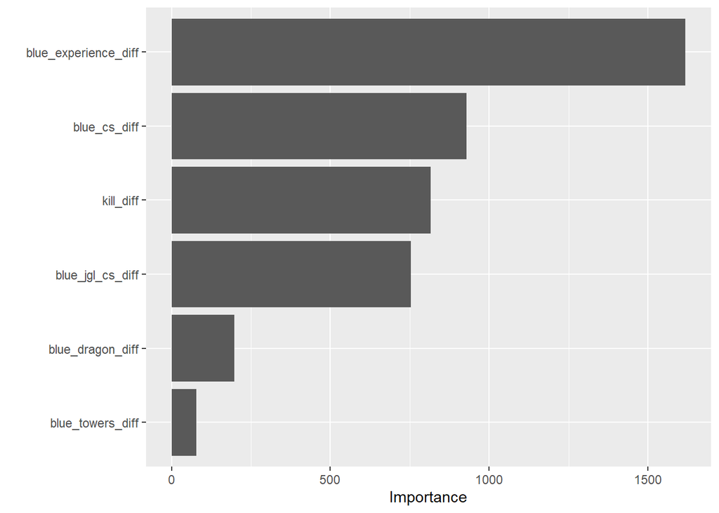

```r
# Random Forest is used to capture complex, non-linear interactions and ranks feature importance without assuming a specific relationship form.
rf <- randomForest(winning_team ~ kill_diff + blue_dragon_diff + blue_cs_diff + blue_jgl_cs_diff + blue_towers_diff + blue_experience_diff, data = lol_df)
vip(rf)
```

```r
# ANOVA is used for understanding the linear relationship and significance of predictors in a parametric model. A higher Chi Sq values indicate that a predictor is more significant
Anova(glm5)
```

```
## Analysis of Deviance Table (Type II tests)
##
## Response: winning_team
##                      LR Chisq Df Pr(>Chisq)
## kill_diff             181.780  1  < 2.2e-16 ***
## blue_dragon_diff      107.550  1  < 2.2e-16 ***
## blue_cs_diff           18.998  1  1.309e-05 ***
## blue_jgl_cs_diff       10.695  1   0.001074 **
## blue_towers_diff        9.918  1   0.001636 **
## blue_experience_diff  104.599  1  < 2.2e-16 ***
## ---
## Signif. codes:  0 '***' 0.001 '**' 0.01 '*' 0.05 '.' 0.1 ' ' 1
```

```r
# ggeffect provides predicted probabilities for the winning_team based on different predictors
ggeffect(glm5)
```

```
## $kill_diff
## # Predicted probabilities of winning_team
##
## kill_diff | Predicted |     95% CI
## ----------------------------------
##       -18 |      0.05 | 0.04, 0.08
##       -14 |      0.10 | 0.07, 0.13
##       -10 |      0.17 | 0.14, 0.21
##        -6 |      0.28 | 0.25, 0.31
##         0 |      0.50 | 0.49, 0.51
##         4 |      0.65 | 0.63, 0.67
##         8 |      0.78 | 0.74, 0.81
##        16 |      0.93 | 0.90, 0.95
```

```
##
## Not all rows are shown in the output. Use `print(..., n = Inf)` to show
##   all rows.
```

```
##
## $blue_dragon_diff
## # Predicted probabilities of winning_team
##
## blue_dragon_diff | Predicted |     95% CI
## -----------------------------------------
##               -1 |      0.43 | 0.41, 0.45
##                0 |      0.50 | 0.49, 0.51
##                1 |      0.58 | 0.56, 0.59
##
##
## $blue_cs_diff
## # Predicted probabilities of winning_team
##
## blue_cs_diff | Predicted |     95% CI
## -------------------------------------
##         -120 |      0.36 | 0.31, 0.43
##          -80 |      0.41 | 0.37, 0.45
##          -60 |      0.43 | 0.40, 0.46
##          -20 |      0.48 | 0.46, 0.49
##           20 |      0.52 | 0.51, 0.54
##           40 |      0.55 | 0.52, 0.57
##           80 |      0.59 | 0.55, 0.63
##          140 |      0.66 | 0.59, 0.72
```

```
##
## Not all rows are shown in the output. Use `print(..., n = Inf)` to show
##   all rows.
```

```
##
## $blue_jgl_cs_diff
## # Predicted probabilities of winning_team
##
## blue_jgl_cs_diff | Predicted |     95% CI
## -----------------------------------------
##              -80 |      0.37 | 0.29, 0.45
##              -60 |      0.40 | 0.34, 0.46
##              -40 |      0.43 | 0.39, 0.47
##              -20 |      0.47 | 0.44, 0.49
##              -10 |      0.48 | 0.47, 0.50
##               10 |      0.52 | 0.50, 0.53
##               30 |      0.55 | 0.52, 0.59
##               70 |      0.62 | 0.55, 0.69
```

```
##
## Not all rows are shown in the output. Use `print(..., n = Inf)` to show
##   all rows.
```

```
##
## $blue_towers_diff
## # Predicted probabilities of winning_team
##
## blue_towers_diff | Predicted |     95% CI
## -----------------------------------------
##               -2 |      0.36 | 0.28, 0.45
##               -1 |      0.43 | 0.38, 0.47
##                0 |      0.50 | 0.49, 0.51
##                1 |      0.57 | 0.52, 0.61
##                2 |      0.64 | 0.55, 0.72
##                3 |      0.70 | 0.58, 0.80
##                4 |      0.76 | 0.60, 0.86
##
##
## $blue_experience_diff
## # Predicted probabilities of winning_team
##
## blue_experience_diff | Predicted |     95% CI
## ---------------------------------------------
##                -9500 |      0.04 | 0.02, 0.08
##                -7000 |      0.09 | 0.06, 0.14
##                -5000 |      0.16 | 0.13, 0.21
##                -3000 |      0.27 | 0.24, 0.31
##                 -500 |      0.46 | 0.45, 0.47
##                 2000 |      0.66 | 0.63, 0.69
##                 4000 |      0.79 | 0.74, 0.83
##                 8500 |      0.94 | 0.90, 0.97
```

```
##
## Not all rows are shown in the output. Use `print(..., n = Inf)` to show
##   all rows.
```

```
##
## attr(,"class")
## [1] "ggalleffects" "list"
## attr(,"model.name")
## [1] "glm5"
```

# Model Evaluation and Validation

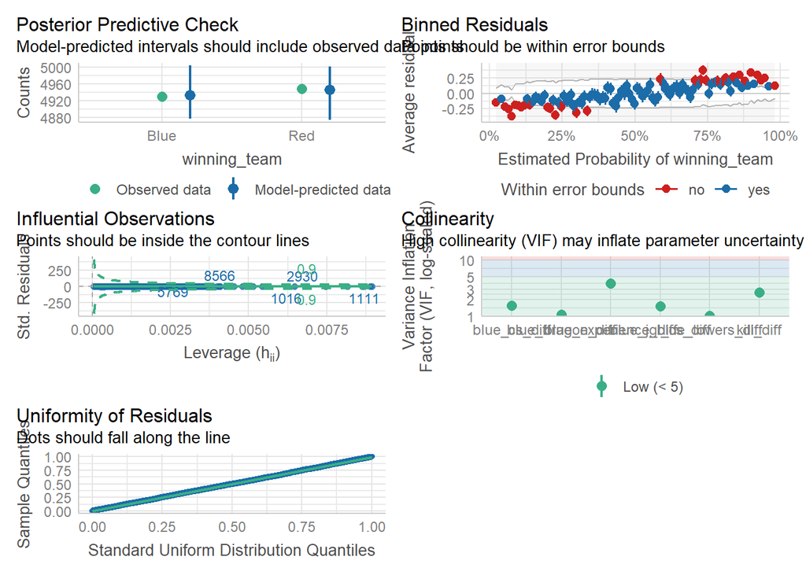

```r
check_model(glm5)
```

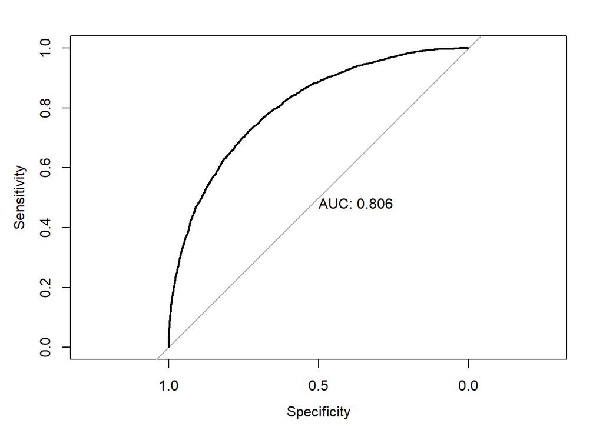

```
##
## Call:
## roc.formula(formula = winning_team ~ fitted.values(glm5), data = lol_df,     plot = TRUE, print.auc = TRUE)
##
## Data: fitted.values(glm5) in 4949 controls (winning_team Red) < 4930 cases (winning_team Blue).
## Area under the curve: 0.8059
```

```r
# ROC curve is produced
roc(winning_team ~ fitted.values(glm5), data = lol_df,
    plot = TRUE, print.auc = TRUE)
```

```r
# Training model is created and data is partitioned
train_model <- glm(winning_team ~ kill_diff + blue_dragon_diff + blue_cs_diff + blue_jgl_cs_diff + blue_dragon_diff + blue_towers_diff + blue_experience_diff, family = binomial, data = lol_df)

set.seed(123)
training_sample <- c(lol_df$winning_team) %>%
  createDataPartition(p = 0.8, list = FALSE)
training_data <- lol_df[training_sample, ]
testing_data <- lol_df[- training_sample, ]
```

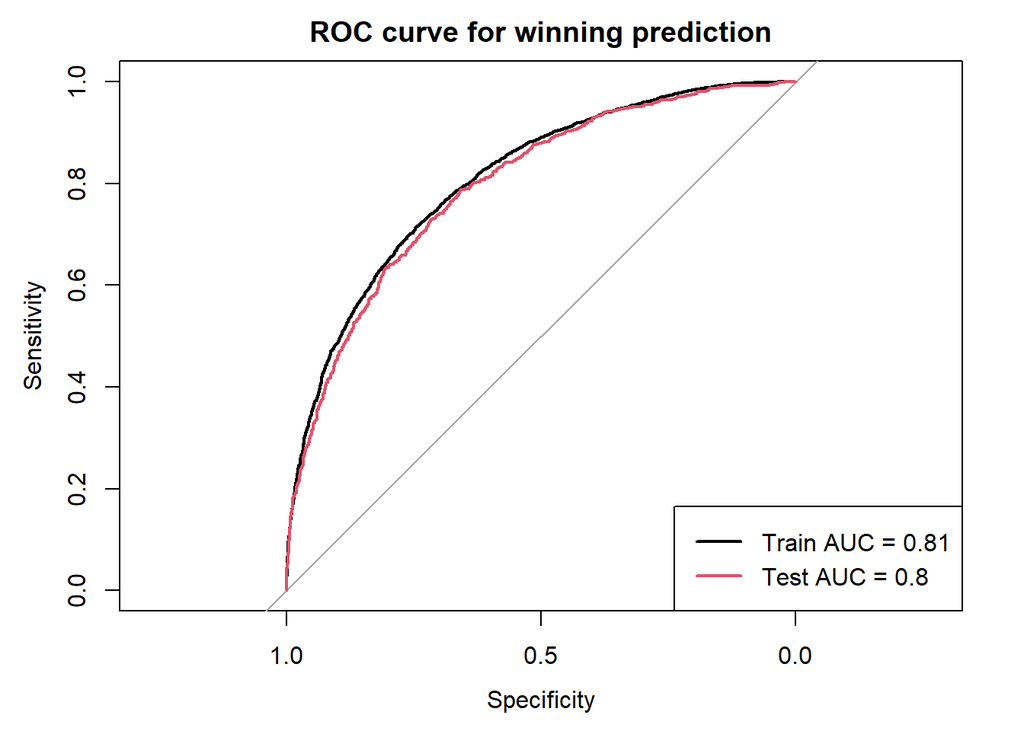

```r
# Predicted probabilities for the training and testing datasets are obtained using the training model
predtrain <- predict(train_model, newdata = training_data, type = "response")
predtest <- predict(train_model, newdata = testing_data, type = "response")

# Calculate and plot ROC curves for training and testing data
roctrain <- roc(response = training_data$winning_team, predictor = predtrain, plot = TRUE, main = "ROC curve for winning prediction", auc = TRUE)
roctest <- roc(response = testing_data$winning_team, predictor = predtest, plot = TRUE, auc = TRUE, add = TRUE, col = 2)
# Calculate AUC values
auc_train <- auc(roctrain)
auc_test <- auc(roctest)

# Add legend
legend("bottomright", legend = c(paste("Train AUC =", round(auc_train, 2)), paste("Test AUC =", round(auc_test, 2))), col = c(1, 2), lwd = 2)
```

# Results analysis and Discussion

The ANOVA (analysis of variance) function was used to assess the significance of predictors in logistic regression model, factoring in their linear relationships and statistical significance. The 3 most important predictors were kill_diff, dragon_diff and experience_diff. Random forest was also used to rank the importance of the predictors. However, it does no assume a specific relationship form and is used to capture complex, non-linear relationships. The 3 most important predictors using RF were experience_diff, blue_cs_diff, kill_diff. Both ranking were used to gain a more comprehensive understanding of the predictors using different modelling techniques.